# STATGR5243 Project 1

ZHI HUANG

1/30/2023

# Introduction

In the long history of philosophy, there are multiple famous pairs of opposite schools. For example, optimist versus pessimist, realist versus idealist, and capitalist versus communist. In this project, I will focus on exploring the differences between empiricism and rationalism. The data set we utilized is built on 360808 sentences from 10 schools. Since we pay more attention on the comparison between empiricism and rationalism, I created two subsets. The sub-data of empiricism has 19931 sentences from Locke, Hume, Berkeley. On the other hand, the dataset of rationalism has 22949 sentences from Spinoza, Leibniz, Descartes, Malebranche.

# Table of content

### Basic visualizations

##### a) Durations

##### b) Length analysis

### Word cloud

### Sentiment Analysis

### Topic Modeling

## 1. Basic visualizations

#### a) Durations

In the first section, to have a basic understanding to two schools, we drew some easy graphs to demonstrate some features. According to the above comparing line graph, rationalism is originated in 1640 and diminished in around 1710, while empiricism was active in between 1690 to 1780. Two schools co-existed for only twenty years in between 1690 to 1710. The way two schools came into people’s eyes are quite different.

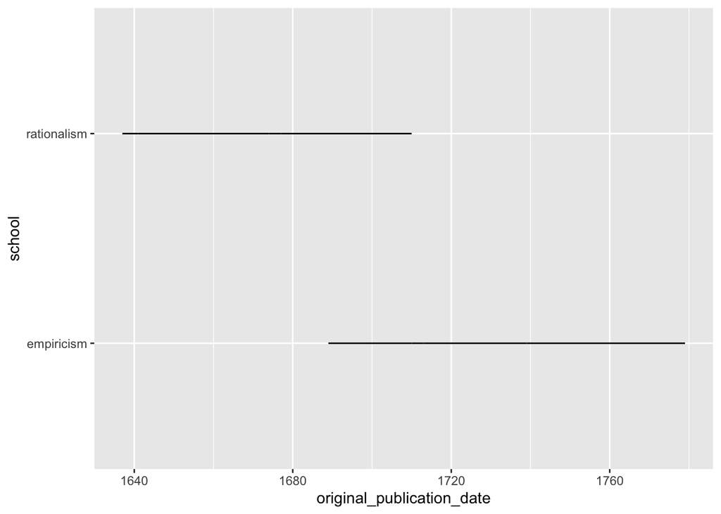

```r
ggplot(comb_df, aes(x=original_publication_date)) +
  geom_line( aes(y=school))
```

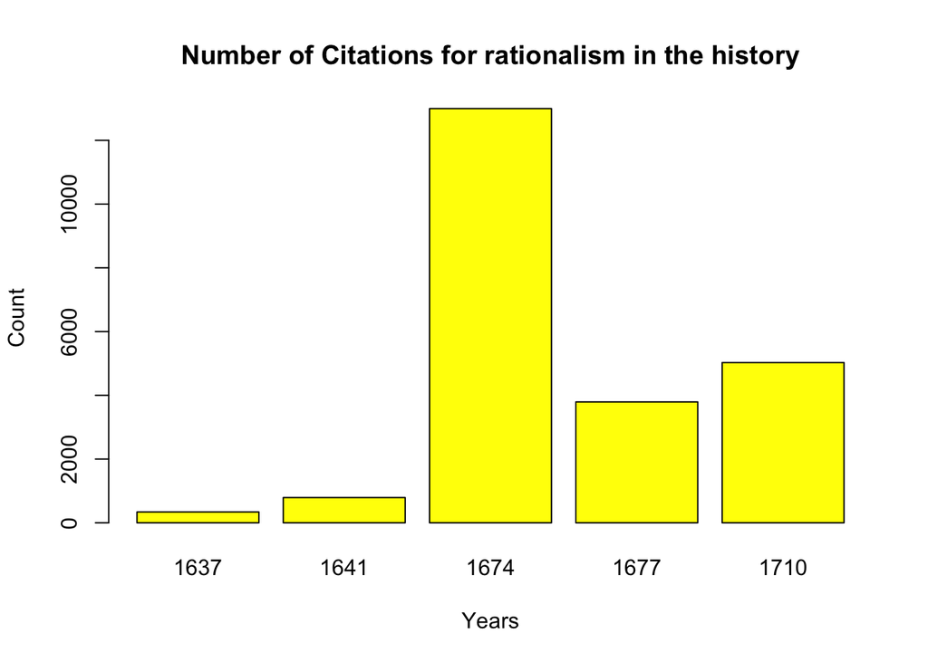

```r
barplot(table(rat_df$original_publication_date),
        main = "Number of Citations for rationalism in the history",
        xlab = "Years",
        ylab = "Count",
        col = "yellow")
```

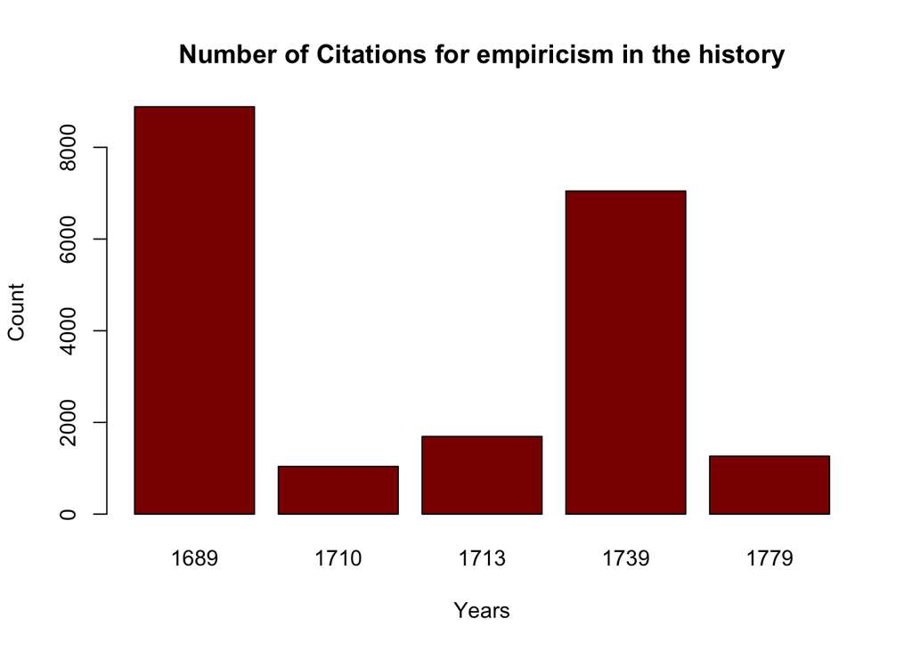

```r
barplot(table(emp_df$original_publication_date),
        main = "Number of Citations for empiricism in the history",
        xlab = "Years",
        ylab = "Count",
        col = "darkred")
```

#### b) Length analysis

Length is an important feature of text analysis. Instead of using length based on letters, we use length based on words, since words are more representative than letters. Another variable is author. Text content is very objective, so we predict different anthers’ expression approaches are different. Through observations, Beeswarm plots splited by writers has shown that majority of the sentences from two schools tend to have less than 100 words. Empiricism sentences’ word count is slightly higher than rationalism sentences’. Descartes from rationalism and Locke from empiricism wrote more long sentences.

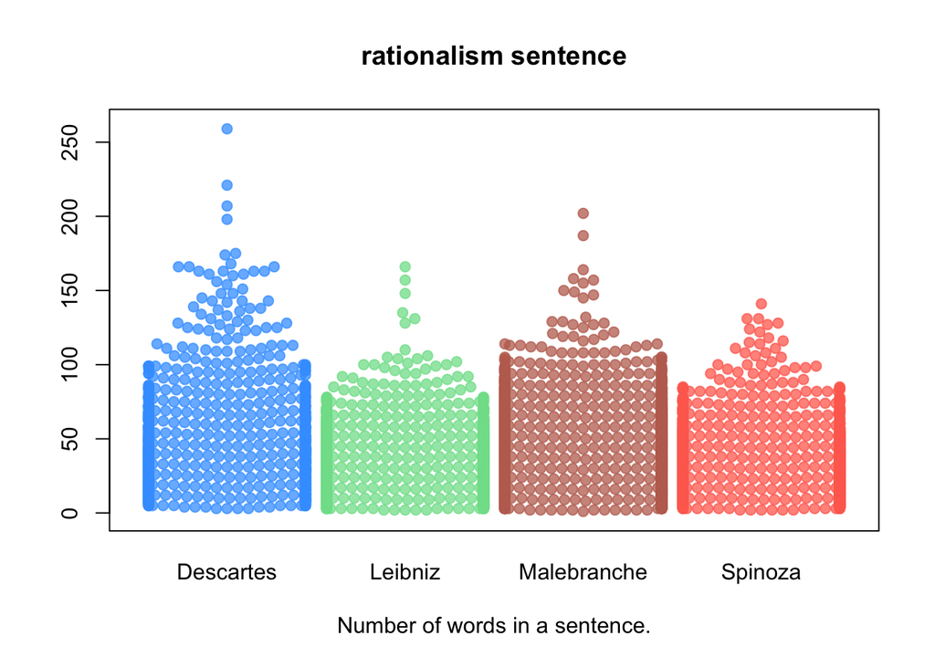

```r
rat_word_count = lengths(gregexpr("\\W+", rat_df$sentence_str))
beeswarm(rat_word_count~rat_df$author,

         pch = 19,
         col = c(rgb(0.25, 0.63, 1, 0.75),
                 rgb(0.5, 0.88, 0.6, 0.75),
                 rgb(0.75, 0.43, 0.37, 0.75),
                 rgb(1, 0.43, 0.37, 0.75)),
         corral = "gutter",
         xlab="Number of words in a sentence.", ylab="",
         main="rationalism sentence")
```

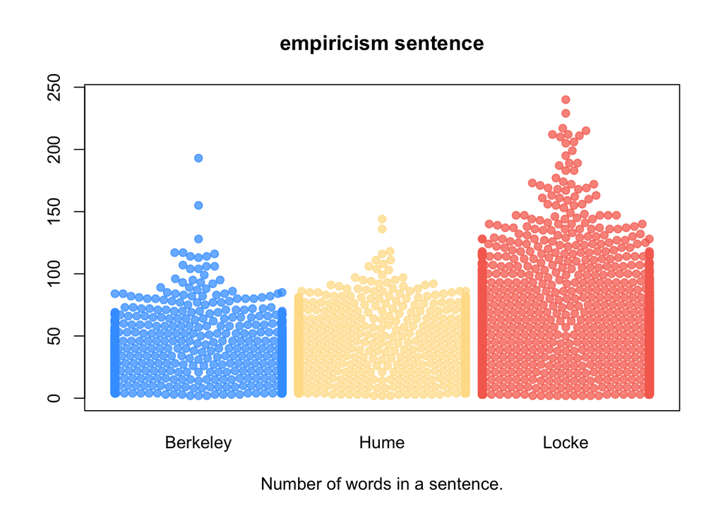

```r
emp_word_count = lengths(gregexpr("\\W+", emp_df$sentence_str))
beeswarm(emp_word_count~emp_df$author,
         pch = 19,
         col = c(rgb(0.25, 0.63, 1, 0.75),
                 rgb(1, 0.88, 0.6, 0.75),
                 rgb(0.97, 0.43, 0.37, 0.75)),
         corral = "gutter",
         xlab="Number of words in a sentence.", ylab="",
         main="empiricism sentence")
```

## 2. Word cloud

According to Participoll’s article, “A Word Cloud is a collection or cluster of words depicted in different sizes. The bigger and bolder the word appears, the more often it is selected/voted for by an audience member.” Word Clouds are a powerful way to visualise what your audience really thinks about a topic. They are easy to read, quick to produce and simple to understand.

#### Empiricism Word Cloud

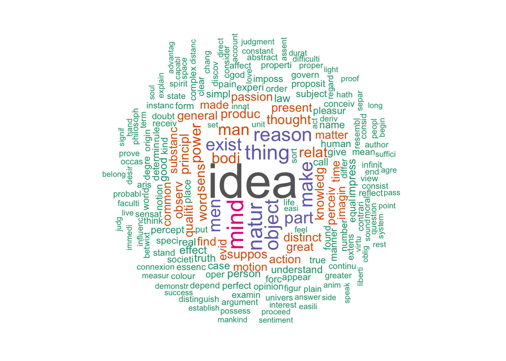

```r
emp_docs <- Corpus(VectorSource(emp_df$sentence_str))
emp_docs <- emp_docs %>%
  tm_map(removeNumbers) %>%
  tm_map(removePunctuation) %>%
  tm_map(stripWhitespace)
emp_docs <- tm_map(emp_docs, content_transformer(tolower))
emp_docs <- tm_map(emp_docs, removeWords, stopwords("smart"))
emp_docs <- tm_map(emp_docs, stemDocument, language = "en")
emp_docs <- tm_map(emp_docs, stripWhitespace)

emp_dtm <- TermDocumentMatrix(emp_docs)
emp_matrix <- as.matrix(emp_dtm)
emp_words <- sort(rowSums(emp_matrix),decreasing=TRUE)
emp_wcdf <- data.frame(word = names(emp_words),freq=emp_words)

wordcloud(words = emp_wcdf$word, freq = emp_wcdf$freq, min.freq = 1,
          max.words=200, random.order=FALSE, rot.per=0.35,
          colors=brewer.pal(8, "Dark2"))
```

The empiricism word cloud is demonstrating a process of human thinking. The noticing words containing idea, mind, reason, distinct, and observe, which proves central idea of empiricism that all learning comes from only experience and observations. There are also plenty “technical” vocabulary, in smaller form, serves for describing human-processing experience–examing, determing, receive, or percept.

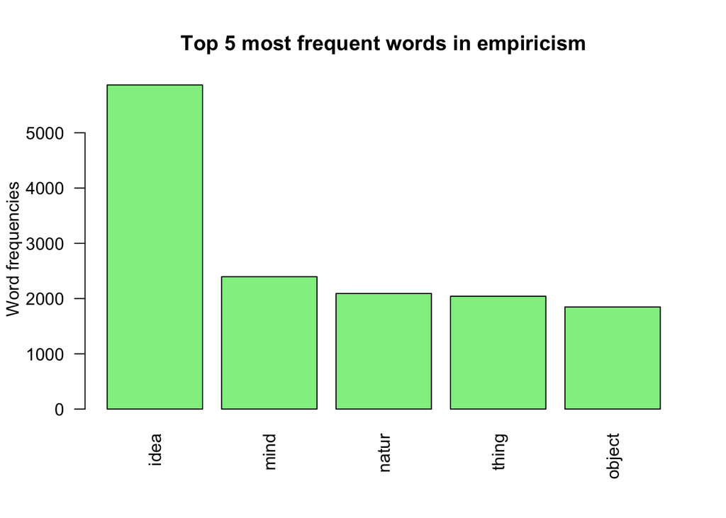

```r
barplot(emp_wcdf[1:5,]$freq, las = 2, names.arg = emp_wcdf[1:5,]$word,
        col ="lightgreen", main ="Top 5 most frequent words in empiricism",
        ylab = "Word frequencies")
```

#### Rationalism Word Cloud

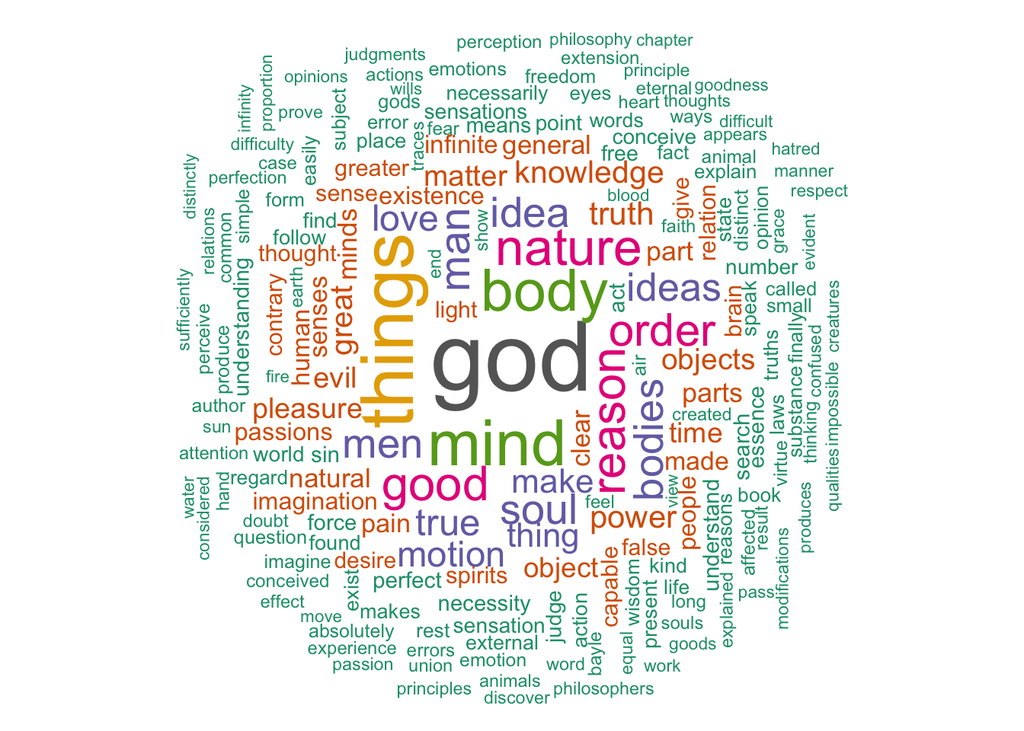

```r
rat_docs <- Corpus(VectorSource(rat_df$sentence_str))
rat_docs <- rat_docs %>%
  tm_map(removeNumbers) %>%
  tm_map(removePunctuation) %>%
  tm_map(stripWhitespace)
rat_docs <- tm_map(rat_docs, content_transformer(tolower))
rat_docs <- tm_map(rat_docs, removeWords, stopwords("smart"))

rat_dtm <- TermDocumentMatrix(rat_docs)
rat_matrix <- as.matrix(rat_dtm)
rat_words <- sort(rowSums(rat_matrix),decreasing=TRUE)
rat_wcdf <- data.frame(word = names(rat_words),freq=rat_words)

wordcloud(words = rat_wcdf$word, freq = rat_wcdf$freq, min.freq = 1,
          max.words=200, random.order=FALSE, rot.per=0.35,
          colors=brewer.pal(8, "Dark2"))
```

The rationalism word cloud is showing a divine sense with a big bold “God” sitting in the middle of the graph. The noticing words containing god, nature, love, soul, mind, and body, which also proves three fundamental claims for rationalism: the deduction thesis, the innate knowledge thesis, or the innate concept thesis. In this school, everything seems was built-in and immutable.

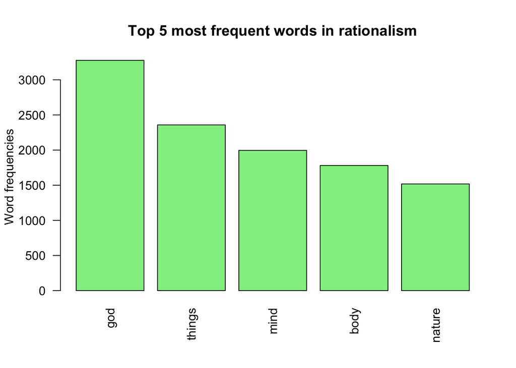

```r
barplot(rat_wcdf[1:5,]$freq, las = 2, names.arg = rat_wcdf[1:5,]$word,
        col ="lightgreen", main ="Top 5 most frequent words in rationalism",
        ylab = "Word frequencies")
```

## 3. Sentiment Analysis

In the third section, we reached to emotional analysis. For each school, we randomly sampled 1000 sentences to run the sentiment analysis. Surprisingly, two contrast schools have similar emotional constitutions. They are all high in positive, negative, and trust; while keep low in disgust, sadness, and surpirse. To amplify the tiny difference of two emotion status, we drew a rader graph.

```r
set.seed(1)
emp_sample = emp_df[sample(nrow(emp_df), 1000),]
emp_sen = get_nrc_sentiment(emp_sample$sentence_str)
head(emp_sen,10)
```

```
##    anger anticipation disgust fear joy sadness surprise trust negative positive
## 1      0            0       0    0   0       0        0     1        0        1
## 2      0            0       0    0   0       0        0     1        0        0
## 3      0            2       0    0   3       0        1     3        0        4
## 4      1            0       0    0   1       0        0     1        0        1
## 5      0            0       0    0   0       0        0     2        0        2
## 6      1            0       0    0   0       0        0     2        1        3
## 7      1            2       1    3   1       1        1     2        3        3
## 8      0            0       0    0   0       0        0     0        0        0
## 9      1            4       0    1   4       0        2     3        0        5
## 10     0            0       0    0   0       0        0     0        0        1
```

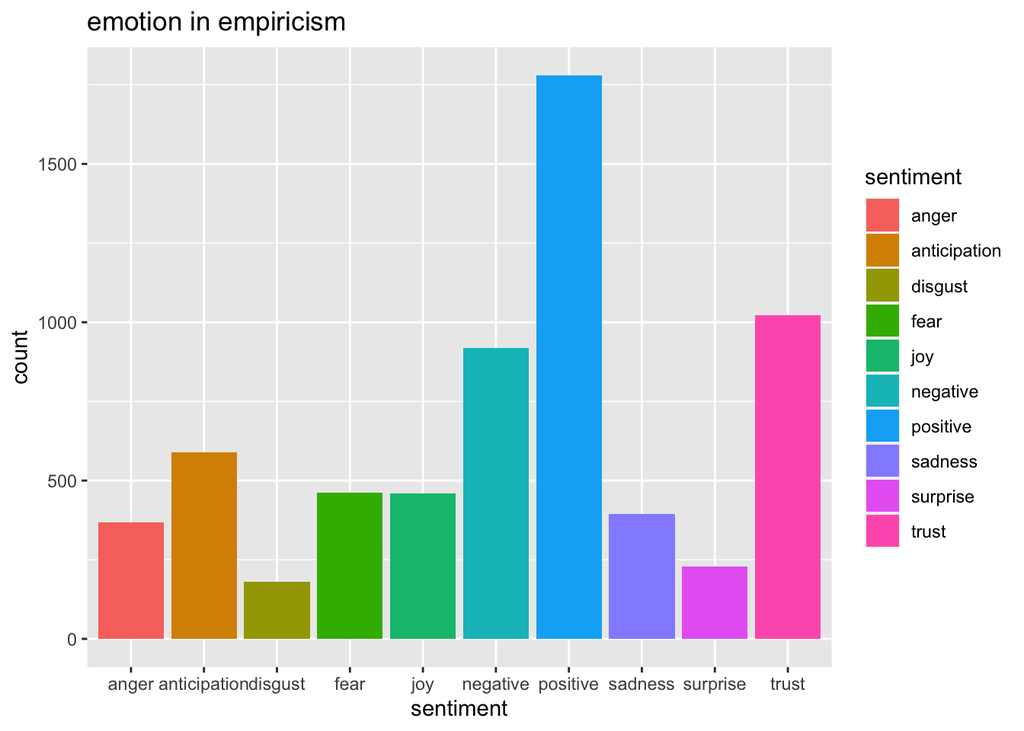

```r
#citation: https://www.red-gate.com/simple-talk/databases/sql-server/bi-sql-server/text-mining-and-sentiment-analysis-with-r/
t_emp_sen<-data.frame(t(emp_sen))
t_emp_sen_new <- data.frame(rowSums(t_emp_sen[2:1000]))
names(t_emp_sen_new)[1] <- "count"
t_emp_sen_new<- cbind("sentiment" = rownames(t_emp_sen_new), t_emp_sen_new)
rownames(t_emp_sen_new) <- NULL
t_emp_sen_new2<-t_emp_sen_new[1:10,]
quickplot(sentiment, data=t_emp_sen_new2, weight=count, geom="bar", fill=sentiment, ylab="count")+ggtitle("emotion in empiricism")
```

```r
set.seed(1)
rat_sample = rat_df[sample(nrow(rat_df), 1000),]
rat_sen = get_nrc_sentiment(rat_sample$sentence_str)
head(rat_sen,10)
```

```
##    anger anticipation disgust fear joy sadness surprise trust negative positive
## 1      0            0       0    0   0       0        0     0        1        0
## 2      0            1       0    0   0       0        1     2        0        1
## 3      0            0       0    0   0       1        0     0        1        0
## 4      1            3       2    3   3       2        0     3        3        3
## 5      0            1       0    0   1       1        1     2        1        1
## 6      0            0       0    0   0       0        0     1        0        1
## 7      1            0       0    1   0       1        0     0        1        0
## 8      1            0       1    0   0       0        0     0        1        0
## 9      1            0       0    3   0       1        0     1        3        2
## 10     0            0       0    0   0       0        0     0        0        1
```

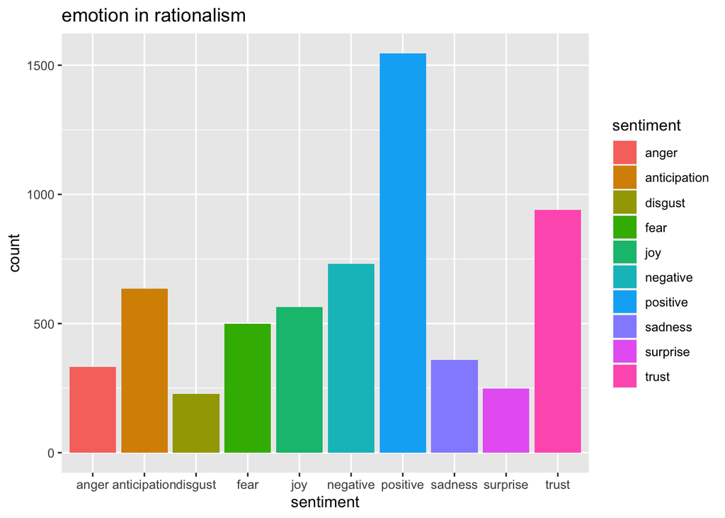

```r
#citation: https://www.red-gate.com/simple-talk/databases/sql-server/bi-sql-server/text-mining-and-sentiment-analysis-with-r/
t_rat_sen<-data.frame(t(rat_sen))
t_rat_sen_new <- data.frame(rowSums(t_rat_sen[2:1000]))
names(t_rat_sen_new)[1] <- "count"
t_rat_sen_new<- cbind("sentiment" = rownames(t_rat_sen_new), t_rat_sen_new)
rownames(t_rat_sen_new) <- NULL
t_rat_sen_new2<-t_rat_sen_new[1:10,]
quickplot(sentiment, data=t_rat_sen_new2, weight=count, geom="bar", fill=sentiment, ylab="count")+ggtitle("emotion in rationalism")
```

```r
t_rat_sen_new3 = data.frame(t(t_rat_sen_new2))
t_rat_sen_new3 = t_rat_sen_new3 %>% row_to_names(row_number = 1)
t_rat_sen_new3 <- t_rat_sen_new3 %>% mutate(across(, ~as.integer(.)))
t_emp_sen_new3 = data.frame(t(t_emp_sen_new2))
t_emp_sen_new3 = t_emp_sen_new3 %>% row_to_names(row_number = 1)
t_emp_sen_new3 <- t_emp_sen_new3 %>% mutate(across(, ~as.integer(.)))

rader = rbind(t_emp_sen_new3 ,t_rat_sen_new3)
rader <- rbind(rep(1500,5) , rep(0,5) , rader)
rownames(rader) <- c("1","2","Empiricisim","Rationalism")
```

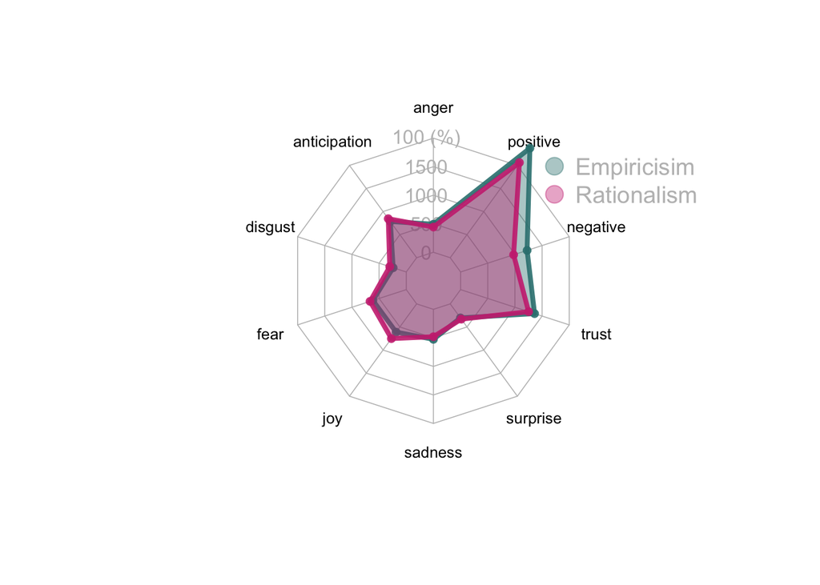

```r
colors_border=c( rgb(0.2,0.5,0.5,0.9), rgb(0.8,0.2,0.5,0.9))
colors_in=c( rgb(0.2,0.5,0.5,0.4), rgb(0.8,0.2,0.5,0.4))

# plot with default options:
radarchart(rader  , axistype=1 ,
    #custom polygon
    pcol=colors_border , pfcol=colors_in , plwd=4 , plty=1,
    #custom the grid
    cglcol="grey", cglty=1, axislabcol="grey", caxislabels=seq(0,1500,500), cglwd=0.8,
    #custom labels
    vlcex=0.8
    )
legend(x=0.7, y=1, legend = rownames(rader[-c(1,2),]), bty = "n", pch=20 , col=colors_in , text.col = "grey", cex=1.2, pt.cex=3)
```

In the rader graph shows that the empiricism is higher in both positive and negative than rationalism is, which could means empiricism has a great variance. On the left bottom cornor of the rader, less joy and more sadness appeared for empiricism. Possibly, potential relationship with high variance mentioned before.

## 4. Topic Modeling

#### Empiricism modeling

```r
minimumFrequency <- 3
emp_dtm2 <- DocumentTermMatrix(emp_docs, control = list(bounds = list(global = c(minimumFrequency, Inf))))
sel_idx <- slam::row_sums(emp_dtm2) > 0
emp_dtm2 <- emp_dtm2[sel_idx, ]

emp_topicModel <- LDA(emp_dtm2, k = 3, method="Gibbs", control = list(seed = 1234))
emp_topics <- tidy(emp_topicModel, matrix = "beta")
emp_top_terms <- emp_topics %>%group_by(topic) %>% top_n(5, beta)%>% ungroup() %>% arrange(topic, -beta)

emp_exampleTermData <- terms(emp_topicModel, 5)
emp_exampleTermData
```

```
##      Topic 1 Topic 2  Topic 3
## [1,] "idea"  "natur"  "object"
## [2,] "mind"  "men"    "reason"
## [3,] "thing" "man"    "relat"
## [4,] "exist" "power"  "produc"
## [5,] "part"  "action" "principl"
```

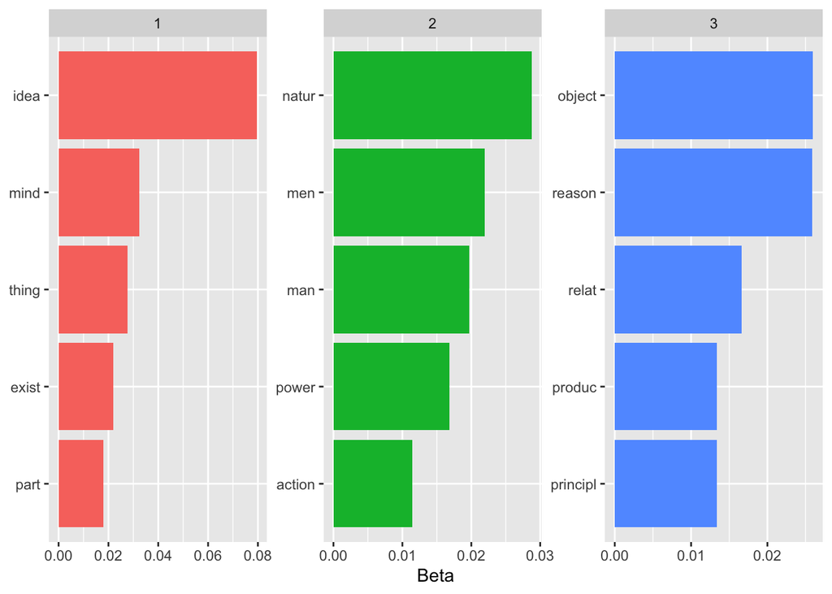

```r
emp_top_terms %>% # take the top terms
          mutate(term = reorder(term, beta)) %>% # sort terms by beta value
          ggplot(aes(term, beta, fill = factor(topic))) + # plot beta by theme
          geom_col(show.legend = FALSE) + # as a bar plot
          facet_wrap(~ topic, scales = "free") + # which each topic in a seperate plot
          labs(x = NULL, y = "Beta") + # no x label, change y label
          coord_flip() # turn bars sideways
```

For the last step of this project, I applied topic modeling on two schools to find out how the main ideas of the two schools differ. We can see the results by generating three topics for each school. For empiricism, the first main topic is about how the mind and things are related, the second is about nature and men, and the third is about the object.

#### Rationalism modeling

```r
minimumFrequency <- 3
rat_dtm2 <- DocumentTermMatrix(rat_docs, control = list(bounds = list(global = c(minimumFrequency, Inf))))
sel_idx <- slam::row_sums(rat_dtm2) > 0
rat_dtm2 <- rat_dtm2[sel_idx, ]

rat_topicModel <- LDA(rat_dtm2, k = 3, method="Gibbs", control = list(seed = 1234))
rat_topics <- tidy(rat_topicModel, matrix = "beta")
rat_top_terms <- rat_topics  %>%group_by(topic) %>% top_n(5, beta)%>% ungroup() %>% arrange(topic, -beta)

rat_exampleTermData <- terms(rat_topicModel, 5)
rat_exampleTermData
```

```
##      Topic 1  Topic 2  Topic 3
## [1,] "body"   "things" "god"
## [2,] "bodies" "mind"   "reason"
## [3,] "soul"   "nature" "good"
## [4,] "motion" "idea"   "order"
## [5,] "great"  "ideas"  "man"
```

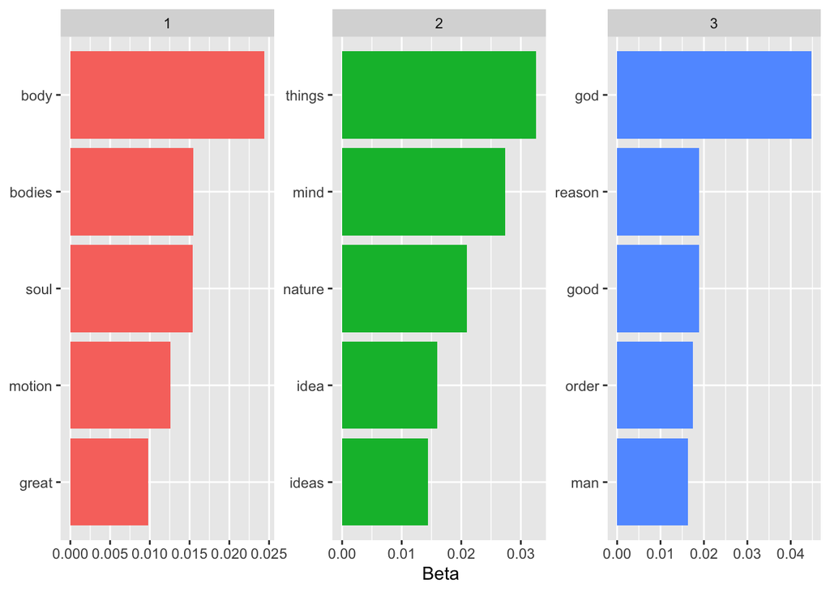

```r
rat_top_terms %>%
          mutate(term = reorder(term, beta)) %>% # sort terms by beta value
          ggplot(aes(term, beta, fill = factor(topic))) + # plot beta by theme
          geom_col(show.legend = FALSE) + # as a bar plot
          facet_wrap(~ topic, scales = "free") + # which each topic in a seperate plot
          labs(x = NULL, y = "Beta") + # no x label, change y label
          coord_flip() # turn bars sideways
```

## Summary

Viewing the difference from the essence, empiricism is learning via past experience and is focusing about human-processing information; rationalism is about innate story, what the nature and the god offers you at the beginning. Though rationalism is often contrasted with empiricism, taken broadly, these views are not mutually exclusive. Especially in the sentimental analysis, where empiricism shared similar emotional track with rationalism.

### Citation:

https://towardsdatascience.com/create-a-word-cloud-with-r-bde3e7422e8a https://www.red-gate.com/simple-talk/databases/sql-server/bi-sql-server/text-mining-and-sentiment-analysis-with-r/ https://www.tidytextmining.com/topicmodeling.html